# Taller Optimización de portafolios (TO 2026-2)

Resuelve el **“Taller Optimización de portafolios”** real (TO 2026-2, octubre 2026): 25 acciones de elección propia, precios diarios 2022-12-31 a 2026-09-30, retornos **semanales**, Sharpe con Rf=0% y Rf=0.216%, un portafolio **media-pérdida esperada (ES/CVaR al 5%)** con 3 variantes (mínimo riesgo, mínimo riesgo a retorno objetivo, máximo Sharpe) y su comparación, un portafolio **media-varianza con pesos entre -5% y 100%** repartido en 4 grupos sectoriales con topes de grupo, y una comparación histórica con retornos **semanales** de los portafolios (rebalanceo mensual) entre el portafolio de máximo Sharpe (ES) y el portafolio con grupos.

## Configuración inicial

```r
if (!require("pacman")) install.packages("pacman")
pacman::p_load(tidyverse, xts, quantmod, TTR,
               stats, zoo, PerformanceAnalytics, PortfolioAnalytics, ROI,
               ROI.plugin.quadprog, ROI.plugin.glpk, readr, scales)
options(scipen = 999)
```

## Parte 0 — Descarga de precios y retornos semanales

Se eligieron las primeras 25 acciones del mismo listado NASDAQ/NYSE usado en el repaso teórico de la unidad (ordenadas por capitalización de mercado) — un criterio objetivo y reproducible, en vez de una selección subjetiva.

```r
companies <- read_csv(file = "https://raw.githubusercontent.com/salas317/Data/main/NASDAQ_NYSE.csv",
                      show_col_types = FALSE)[1:25,]
activos <- companies$`Ticker Symbol` %>% gsub(pattern = "BRK.A", x = ., replacement = "BRK-A")
activos
```

```
##  [1] "NVDA"  "AAPL"  "GOOGL" "MSFT"  "AMZN"  "AVGO"  "META"  "TSLA"  "LLY"
## [10] "BRK-A" "MU"    "JPM"   "WMT"   "AMD"   "V"     "JNJ"   "MA"    "INTC"
## [19] "ABBV"  "CSCO"  "BAC"   "ORCL"  "COST"  "CVX"   "LRCX"
```

```r
precios <- quantmod::getSymbols(activos, src = 'yahoo',
                                from = "2022-12-31",
                                to = "2026-09-30",
                                periodicity = "daily",
                                auto.assign = T,
                                warnings = F) %>%
  purrr::map(~quantmod::Ad(get(.))) %>%
  purrr::reduce(merge.xts) %>%
  `colnames<-`(activos)

retornos_semana <- precios %>%
  xts::to.weekly(OHLC = FALSE) %>%
  log() %>%
  diff() %>%
  na.omit()
tail(retornos_semana[, 1:5])
```

```
##                    NVDA         AAPL         GOOGL         MSFT         AMZN
## 2026-08-28  0.013093814  0.032909753  0.0051199742  0.060795103  0.029713030
## 2026-09-04  0.057214606  0.000844151 -0.0230940848 -0.027300565 -0.030177102
## 2026-09-11 -0.052700542  0.037720613  0.0001182006 -0.008178252 -0.006714733
## 2026-09-18  0.018068455  0.011550146  0.0320939364 -0.003739619 -0.012027773
## 2026-09-25  0.012518619  0.014589752 -0.0162089176  0.044346064 -0.016051870
## 2026-09-29  0.009463232 -0.034814957 -0.0087612262 -0.014066724 -0.012088635
```

**Hallazgo real (calidad de dato)**: igual que en el ejercicio de clase de esta misma unidad, se verificó que `TTR::ROC(type="continuous", na.pad=FALSE)` sobre esta matriz xts de 25 columnas produce retornos corruptos en la primera fila de algunos activos (mismo bug ya documentado en varios talleres del curso, causado por la combinación de librerías cargadas). Se usa `diff(log(x))` en su lugar, que da el retorno logarítmico correcto y no tiene ese problema. Se revisaron los extremos de `retornos_semana` y no hay valores fuera de rango razonable.

```r
range(retornos_semana)
```

```
## [1] -0.3780920  0.3201573
```

## 1 — Sharpe Ratio por acción, Rf = 0.000%

```r
sharpe_rf0 <- PerformanceAnalytics::SharpeRatio(R = retornos_semana, Rf = 0, FUN = "StdDev")
sharpe_rf0
```

```
##                                   NVDA      AAPL     GOOGL      MSFT      AMZN
## Sharpe Ratio (Rf=0%, p=95%): 0.2300556 0.1349923 0.1621948 0.1194625 0.1294197
##                                   AVGO      META       TSLA       LLY     BRK-A
## Sharpe Ratio (Rf=0%, p=95%): 0.1472776 0.1694874 0.07826052 0.1281142 0.1076568
##                                     MU       JPM      WMT       AMD         V
## Sharpe Ratio (Rf=0%, p=95%): 0.1880252 0.1548054 0.142106 0.1566399 0.1125193
##                                   JNJ       MA       INTC       ABBV      CSCO
## Sharpe Ratio (Rf=0%, p=95%): 0.101497 0.090406 0.08986497 0.08604628 0.1314038
##                                     BAC       ORCL      COST        CVX
## Sharpe Ratio (Rf=0%, p=95%): 0.07521167 0.04272366 0.1357802 0.04757698
##                                   LRCX
## Sharpe Ratio (Rf=0%, p=95%): 0.1681814
```

**Respuesta**: con Rf = 0% las 25 acciones tienen Sharpe positivo. Los más altos son NVDA (0,230), MU (0,188) y META (0,169); los más bajos, ORCL (0,043), CVX (0,048) y BAC (0,075).

## 2 — Sharpe Ratio por acción, Rf = 0.216%

```r
rf_semanal <- 0.00216
sharpe_rf1 <- PerformanceAnalytics::SharpeRatio(R = retornos_semana, Rf = rf_semanal, FUN = "StdDev")
sharpe_rf1
```

```
##                                     NVDA       AAPL     GOOGL       MSFT
## Sharpe Ratio (Rf=0.2%, p=95%): 0.1945692 0.07516347 0.1123764 0.06002281
##                                      AMZN     AVGO      META       TSLA
## Sharpe Ratio (Rf=0.2%, p=95%): 0.07764072 0.113708 0.1286208 0.04929694
##                                       LLY       BRK-A        MU        JPM
## Sharpe Ratio (Rf=0.2%, p=95%): 0.08357366 0.006146318 0.1611499 0.08743974
##                                       WMT       AMD          V       JNJ
## Sharpe Ratio (Rf=0.2%, p=95%): 0.06942777 0.1273327 0.02596384 0.0163716
##                                         MA       INTC     ABBV       CSCO
## Sharpe Ratio (Rf=0.2%, p=95%): 0.005403391 0.06342192 0.024743 0.06911956
##                                       BAC        ORCL       COST         CVX
## Sharpe Ratio (Rf=0.2%, p=95%): 0.01892859 0.008254941 0.05349917 -0.01924471
##                                     LRCX
## Sharpe Ratio (Rf=0.2%, p=95%): 0.1330876
```

**Respuesta**: al subir Rf a 0,216% semanal todos los Sharpe bajan, porque se resta más al numerador. El orden de las mejores casi no cambia (NVDA 0,195, MU 0,161, LRCX 0,133), pero las de menor retorno esperado caen mucho en proporción: CVX pasa a negativo (−0,019) y MA, BRK-A y ORCL quedan cerca de cero. Con Rf = 0,216% solo 24 de las 25 acciones tienen Sharpe positivo.

## 3 — Portafolio de media-pérdida esperada (ES al 5%)

Condiciones: full investment, long only (sin short-selling), sin activo libre de riesgo, riesgo medido como Expected Shortfall al 5% (el percentil 95 de pérdida).

```r
init.portfolio <- PortfolioAnalytics::portfolio.spec(assets = activos, name = "Portafolio ES")
init.portfolio <- PortfolioAnalytics::add.constraint(portfolio = init.portfolio, type = "full_investment")
init.portfolio <- PortfolioAnalytics::add.constraint(portfolio = init.portfolio, type = "long_only")
```

### 3.1 — Frontera eficiente (media-ES)

```r
frontera_es <- PortfolioAnalytics::create.EfficientFrontier(R = retornos_semana,
                                                         portfolio = init.portfolio,
                                                         type = 'mean-ES',
                                                         n.portfolios = 50)
```

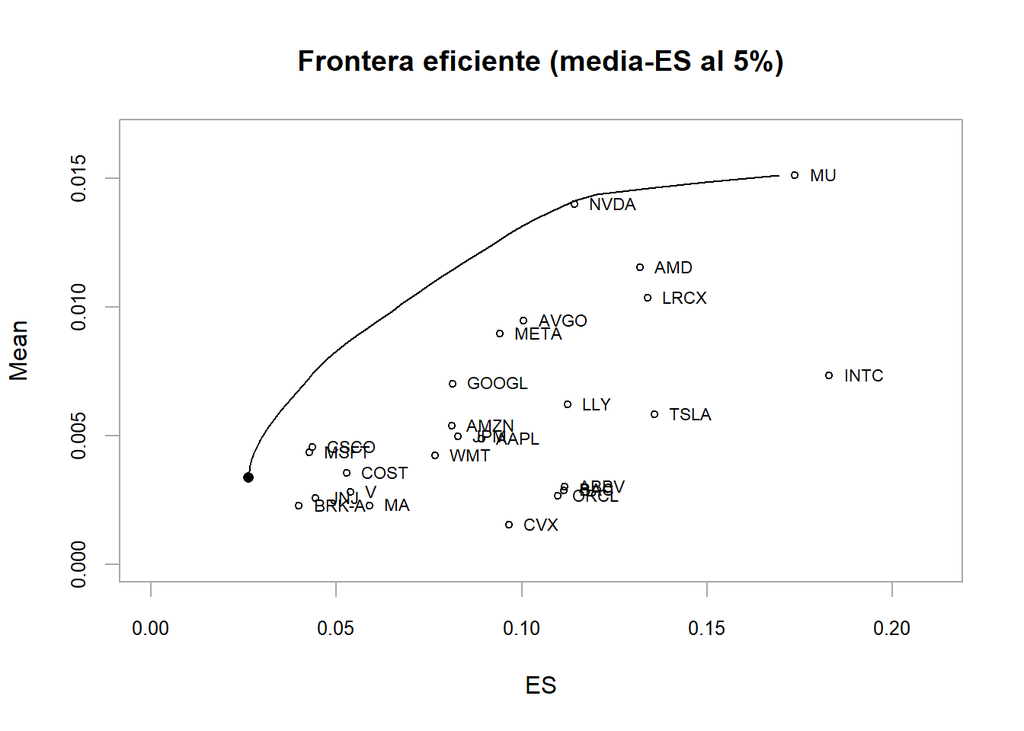

```r
PortfolioAnalytics::chart.EfficientFrontier(frontera_es,
                                            match.col = 'ES',
                                            type = 'l',
                                            rf = NULL,
                                            main = "Frontera eficiente (media-ES al 5%)",
                                            cex.assets = 0.7)
```

### 3.2 — Frontera eficiente con Rf = 0.216%

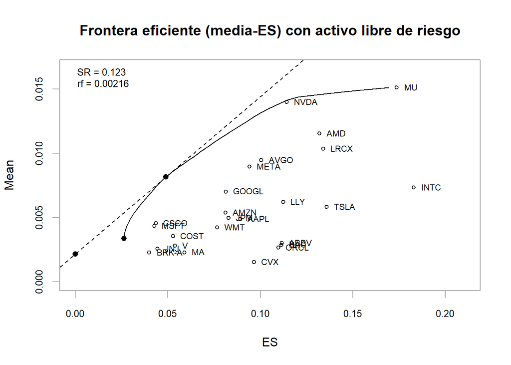

```r
PortfolioAnalytics::chart.EfficientFrontier(frontera_es,
                                            match.col = 'ES',
                                            type = 'l',
                                            rf = rf_semanal,
                                            main = "Frontera eficiente (media-ES) con activo libre de riesgo",
                                            cex.assets = 0.7)
```

### 3.3 — Portafolio de mínimo riesgo (ES)

```r
risk.portfolio.es <- PortfolioAnalytics::add.objective(portfolio = init.portfolio, type = "risk", name = "ES", arguments = list(p = 0.95))
opt.minrisk.es <- PortfolioAnalytics::optimize.portfolio(R = retornos_semana,
                                                      portfolio = risk.portfolio.es,
                                                      optimize_method = "ROI",
                                                      trace = T)
opt.minrisk.es
```

```
## PortfolioAnalytics Optimization
##
## Call:
## PortfolioAnalytics::optimize.portfolio(R = retornos_semana, portfolio = risk.portfolio.es,
##     optimize_method = "ROI", trace = T)
##
## Optimal Weights:
##   NVDA   AAPL  GOOGL   MSFT   AMZN   AVGO   META   TSLA    LLY  BRK-A     MU
## 0.0000 0.0000 0.0000 0.1558 0.0000 0.0000 0.0000 0.0000 0.0000 0.1897 0.0000
##    JPM    WMT    AMD      V    JNJ     MA   INTC   ABBV   CSCO    BAC   ORCL
## 0.0000 0.1159 0.0197 0.1956 0.2874 0.0000 0.0000 0.0000 0.0000 0.0000 0.0000
##   COST    CVX   LRCX
## 0.0163 0.0000 0.0195
##
## Objective Measure:
##      ES
## 0.02634
```

```r
sharpe_minrisk_es <- SharpeRatio(R = retornos_semana, Rf = rf_semanal, weights = opt.minrisk.es$weights, FUN = "StdDev")
sharpe_minrisk_es
```

```
##                                      [,1]
## Sharpe Ratio (Rf=0.2%, p=95%): 0.07949533
```

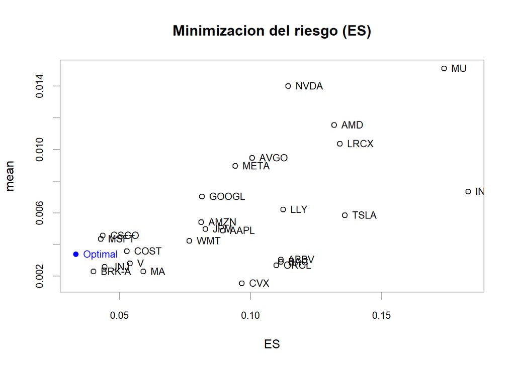

```r
PortfolioAnalytics::chart.RiskReward(opt.minrisk.es, risk.col = "ES", return.col = "mean",
                                     chart.assets = TRUE, rp = F, main = "Minimizacion del riesgo (ES)")
```

**a. ¿Cómo está compuesto?**

**Respuesta a.** El portafolio de mínimo ES (ES ≈ 2,63% semanal) usa solo 8 de las 25 acciones: JNJ 28,7%, V 19,6%, BRK-A 19,0%, MSFT 15,6%, WMT 11,6%, AMD 2,0%, LRCX 2,0% y COST 1,6%. Las otras 17 quedan en cero. Se apoya en acciones de baja volatilidad (JNJ, V, BRK-A, WMT) más MSFT.

**b. Ratio de Sharpe y comparación con las acciones individuales**

**Respuesta b.** Su Sharpe es 0,0795 (Rf = 0,216%). Es bajo frente a las mejores acciones (NVDA 0,195, MU 0,161) y superior al de unas 16 de las 25. Aun así, su desviación semanal (1,53%) es menor que la de cualquier acción individual (la menor es BRK-A, 2,13%): es el efecto de la diversificación. Minimiza el riesgo sin buscar retorno, por eso queda en el extremo izquierdo de la frontera.

### 3.4 — Portafolio de mínimo riesgo (ES), retorno objetivo

```r
retorno_objetivo <- 0.005 # 0.5% semanal, elegido por nosotros
risk.target.es <- PortfolioAnalytics::add.constraint(portfolio = init.portfolio, type = "return", return_target = retorno_objetivo)
risk.target.es <- PortfolioAnalytics::add.objective(portfolio = risk.target.es, type = "risk", name = "ES", arguments = list(p = 0.95))
opt.target.es <- PortfolioAnalytics::optimize.portfolio(R = retornos_semana,
                                                     portfolio = risk.target.es,
                                                     optimize_method = "ROI",
                                                     trace = T)
opt.target.es
```

```
## PortfolioAnalytics Optimization
##
## Call:
## PortfolioAnalytics::optimize.portfolio(R = retornos_semana, portfolio = risk.target.es,
##     optimize_method = "ROI", trace = T)
##
## Optimal Weights:
##   NVDA   AAPL  GOOGL   MSFT   AMZN   AVGO   META   TSLA    LLY  BRK-A     MU
## 0.0519 0.0000 0.0442 0.1387 0.0000 0.0000 0.0205 0.0000 0.0000 0.0469 0.0231
##    JPM    WMT    AMD      V    JNJ     MA   INTC   ABBV   CSCO    BAC   ORCL
## 0.0000 0.2084 0.0689 0.0199 0.3693 0.0000 0.0000 0.0000 0.0083 0.0000 0.0000
##   COST    CVX   LRCX
## 0.0000 0.0000 0.0000
##
## Objective Measure:
##     ES
## 0.0302
```

```r
sharpe_target_es <- SharpeRatio(R = retornos_semana, Rf = rf_semanal, weights = opt.target.es$weights, FUN = "StdDev")
sharpe_target_es
```

```
##                                     [,1]
## Sharpe Ratio (Rf=0.2%, p=95%): 0.1615205
```

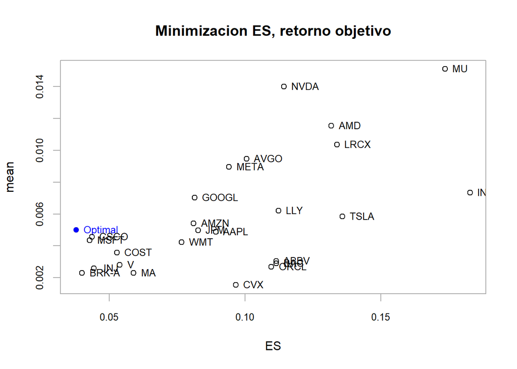

```r
PortfolioAnalytics::chart.RiskReward(opt.target.es, risk.col = "ES", return.col = "mean",
                                     chart.assets = TRUE, rp = F, main = "Minimizacion ES, retorno objetivo")
```

**a. ¿Cómo está compuesto?**

**Respuesta a.** Se eligió un retorno objetivo de 0,5% semanal (≈26% anual simple), intermedio entre el retorno del portafolio de mínimo riesgo (0,34%) y el del máximo Sharpe (0,65%). El portafolio usa 11 acciones: JNJ 36,9%, WMT 20,8%, MSFT 13,9%, AMD 6,9%, NVDA 5,2%, BRK-A 4,7%, GOOGL 4,4%, MU 2,3%, META 2,1%, V 2,0% y CSCO 0,8%. Para subir el retorno incorpora tecnológicas (AMD, NVDA, GOOGL, MU, META) y mantiene JNJ y WMT para controlar el ES (≈3,02% semanal).

**b. Ratio de Sharpe y comparación con las acciones**

**Respuesta b.** Su Sharpe es 0,1615, el doble que el del mínimo riesgo (0,0795). Solo NVDA (0,195) lo supera; MU (0,161) queda prácticamente igual. Supera al resto de las acciones individuales, con una desviación semanal de 1,76%.

**c. Posición en la frontera eficiente**

**Respuesta c.** Es un punto intermedio de la frontera: a la derecha del portafolio de mínimo riesgo (más retorno y más ES) y a la izquierda del portafolio tangente (máximo Sharpe).

### 3.5 — Portafolio que maximiza el Sharpe Ratio (esquema ES)

```r
sr.portfolio.es <- PortfolioAnalytics::add.objective(portfolio = init.portfolio, type = "risk", name = "ES", arguments = list(p = 0.95))
sr.portfolio.es <- PortfolioAnalytics::add.objective(portfolio = sr.portfolio.es, type = "return", name = "mean")
opt.sr.es <- PortfolioAnalytics::optimize.portfolio(R = retornos_semana,
                                                 portfolio = sr.portfolio.es,
                                                 optimize_method = "ROI",
                                                 trace = T,
                                                 maxSR = TRUE)
opt.sr.es
```

```
## PortfolioAnalytics Optimization
##
## Call:
## PortfolioAnalytics::optimize.portfolio(R = retornos_semana, portfolio = sr.portfolio.es,
##     optimize_method = "ROI", trace = T, maxSR = TRUE)
##
## Optimal Weights:
##   NVDA   AAPL  GOOGL   MSFT   AMZN   AVGO   META   TSLA    LLY  BRK-A     MU
## 0.1344 0.0000 0.1810 0.0198 0.0000 0.0000 0.0628 0.0000 0.0000 0.0000 0.0201
##    JPM    WMT    AMD      V    JNJ     MA   INTC   ABBV   CSCO    BAC   ORCL
## 0.0000 0.2092 0.0490 0.0118 0.2740 0.0000 0.0000 0.0000 0.0377 0.0000 0.0000
##   COST    CVX   LRCX
## 0.0000 0.0000 0.0000
##
## Objective Measure:
##     mean
## 0.006468
##
##
##      ES
## 0.03784
```

```r
sharpe_sr_es <- SharpeRatio(R = retornos_semana, Rf = rf_semanal, weights = opt.sr.es$weights, FUN = "StdDev")
sharpe_sr_es
```

```
##                                     [,1]
## Sharpe Ratio (Rf=0.2%, p=95%): 0.2015291
```

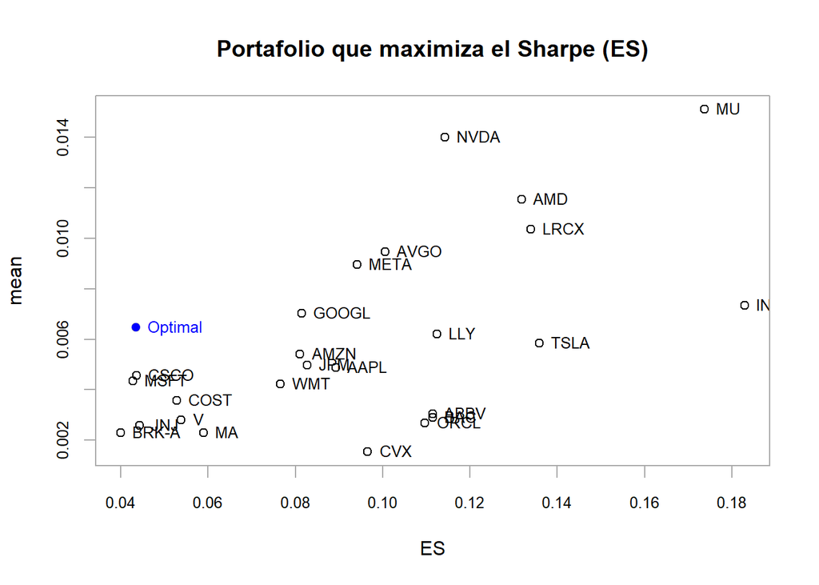

```r
PortfolioAnalytics::chart.RiskReward(opt.sr.es, risk.col = "ES", return.col = "mean",
                                     chart.assets = TRUE, rp = F, main = "Portafolio que maximiza el Sharpe (ES)")
```

**a. ¿Cómo está compuesto?**

**Respuesta a.** El portafolio de máximo Sharpe (esquema ES) usa 10 acciones: JNJ 27,4%, WMT 20,9%, GOOGL 18,1%, NVDA 13,4%, META 6,3%, AMD 4,9%, CSCO 3,8%, MU 2,0%, MSFT 2,0% y V 1,2%. Combina defensivas (JNJ, WMT) con tecnológicas de alto retorno (GOOGL, NVDA, META).

**b. Ratio de Sharpe y comparación con las acciones**

**Respuesta b.** Su Sharpe es 0,2015, mayor que el de todas las acciones individuales (la mejor, NVDA, 0,195). Su retorno es 0,65% semanal con desviación de 2,14%.

### 3.6 — Comparación de los 3 portafolios (ES)

```r
tabla_3 <- data.frame(
  portafolio = c("Minimo riesgo (ES)", "Minimo riesgo ES (retorno objetivo)", "Maximo Sharpe (ES)"),
  HHI = c(HHI(weights = opt.minrisk.es$weights), HHI(weights = opt.target.es$weights), HHI(weights = opt.sr.es$weights)),
  Sharpe = c(as.numeric(sharpe_minrisk_es), as.numeric(sharpe_target_es), as.numeric(sharpe_sr_es))
)
tabla_3
```

```
##                            portafolio       HHI     Sharpe
## 1                  Minimo riesgo (ES) 0.1956408 0.07949533
## 2 Minimo riesgo ES (retorno objetivo) 0.2120526 0.16152047
## 3                  Maximo Sharpe (ES) 0.1783998 0.20152910
```

**a. Diversificación**

**Respuesta a.** Con el HHI (menor = más diversificado) el portafolio más diversificado es el de máximo Sharpe (0,178, ≈5,6 acciones efectivas), seguido por el de mínimo riesgo (0,196, ≈5,1) y por último el de retorno objetivo (0,212, ≈4,7), que es el más concentrado porque carga mucho en JNJ (36,9%).

**b. Prima de retorno por unidad de riesgo (Sharpe)**

**Respuesta b.** El Sharpe sube de forma monótona: mínimo riesgo 0,0795 → retorno objetivo 0,1615 → máximo Sharpe 0,2015. Cada portafolio exige más retorno por unidad de riesgo que el anterior, y solo el de máximo Sharpe supera a todas las acciones individuales.

## 4 — Portafolio media-varianza con pesos entre -5% y 100%, por grupos

Condiciones: media-varianza (StdDev como riesgo, media como retorno), full investment, sin activo libre de riesgo, peso de cada acción entre -0.05 y 1 (permite un short-selling limitado), 3-4 grupos con peso total entre -0.1 y 0.6 cada uno.

**Criterio de agrupación**: se clasificaron las 25 acciones en 4 grupos sectoriales con base en su negocio principal — **Tecnología** (semiconductores, software, hardware, internet: 12 acciones, el grupo más grande, reflejo de que la mayoría de las empresas de mayor capitalización del listado son tecnológicas), **Financiero** (bancos, medios de pago, conglomerado: 5), **Consumo** (discrecional y defensivo: 4) y **Salud y Energía** (defensivas no-consumo: 4).

```r
grupo_map <- c(
  NVDA="Tech", AAPL="Tech", GOOGL="Tech", MSFT="Tech", AVGO="Tech",
  META="Tech", MU="Tech", AMD="Tech", INTC="Tech", CSCO="Tech", ORCL="Tech", LRCX="Tech",
  "BRK-A"="Financiero", JPM="Financiero", V="Financiero", MA="Financiero", BAC="Financiero",
  AMZN="Consumo", TSLA="Consumo", WMT="Consumo", COST="Consumo",
  LLY="Salud_Energia", JNJ="Salud_Energia", ABBV="Salud_Energia", CVX="Salud_Energia"
)
grupo_map <- grupo_map[activos]
table(grupo_map)
```

```
## grupo_map
##       Consumo    Financiero Salud_Energia          Tech
##             4             5             4            12
```

```r
grupos_idx <- list(
  which(grupo_map == "Tech"),
  which(grupo_map == "Financiero"),
  which(grupo_map == "Consumo"),
  which(grupo_map == "Salud_Energia")
)

box.g.portfolio <- PortfolioAnalytics::portfolio.spec(assets = activos, name = "Portafolio MV grupos")
box.g.portfolio <- PortfolioAnalytics::add.constraint(portfolio = box.g.portfolio, type = "full_investment")
box.g.portfolio <- PortfolioAnalytics::add.constraint(portfolio = box.g.portfolio, type = "box", min = -0.05, max = 1)
box.g.portfolio <- PortfolioAnalytics::add.constraint(portfolio = box.g.portfolio, type = "group",
                                                       groups = grupos_idx,
                                                       group_min = -0.1, group_max = 0.6)
box.g.portfolio <- PortfolioAnalytics::add.objective(portfolio = box.g.portfolio, type = "risk", name = "StdDev")
box.g.portfolio <- PortfolioAnalytics::add.objective(portfolio = box.g.portfolio, type = "return", name = "mean")

opt.box.g <- PortfolioAnalytics::optimize.portfolio(R = retornos_semana,
                                                  portfolio = box.g.portfolio,
                                                  optimize_method = "ROI",
                                                  trace = T,
                                                  maxSR = TRUE)
opt.box.g
```

```
## PortfolioAnalytics Optimization
##
## Call:
## PortfolioAnalytics::optimize.portfolio(R = retornos_semana, portfolio = box.g.portfolio,
##     optimize_method = "ROI", trace = T, maxSR = TRUE)
##
## Optimal Weights:
##    NVDA    AAPL   GOOGL    MSFT    AMZN    AVGO    META    TSLA     LLY   BRK-A
##  0.1811 -0.0253  0.1677  0.0278 -0.0002 -0.0500  0.0710 -0.0262  0.0494  0.0738
##      MU     JPM     WMT     AMD       V     JNJ      MA    INTC    ABBV    CSCO
##  0.0876  0.1682  0.1403  0.0258 -0.0500  0.2512 -0.0500 -0.0323  0.0763 -0.0104
##     BAC    ORCL    COST     CVX    LRCX
## -0.0500 -0.0500  0.0754 -0.0013 -0.0498
##
## Objective Measure:
##  StdDev
## 0.02006
##
##
##     mean
## 0.007056
```

```r
sharpe_box_g <- SharpeRatio(R = retornos_semana, Rf = rf_semanal, weights = opt.box.g$weights, FUN = "StdDev")
sharpe_box_g
```

```
##                                     [,1]
## Sharpe Ratio (Rf=0.2%, p=95%): 0.2440311
```

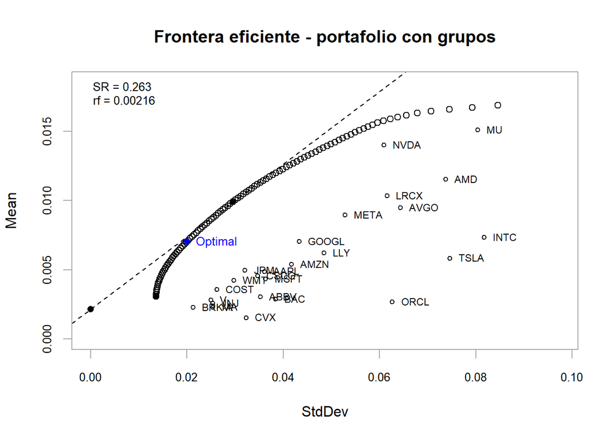

```r
PortfolioAnalytics::chart.EfficientFrontier(opt.box.g,
                                            match.col = 'StdDev',
                                            main = "Frontera eficiente - portafolio con grupos",
                                            cex.assets = 0.7,
                                            tangent.line = T,
                                            n.portfolios = 100,
                                            rf = rf_semanal)
```

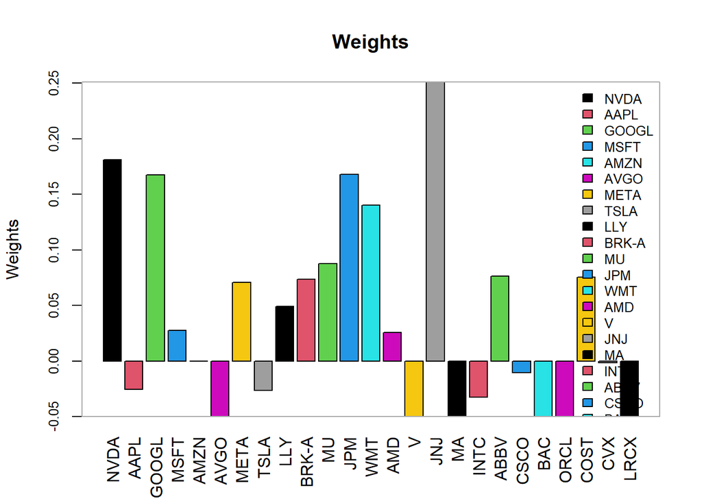

```r
chart.Weights(opt.box.g, plot.type = "barplot")
```

```r
apalancamiento <- sum(abs(opt.box.g$weights))
apalancamiento
```

```
## [1] 1.791029
```

```r
tabla_4 <- data.frame(
  portafolio = c("Maximo Sharpe (ES, sin grupos)", "Maximo Sharpe (MV, con grupos y short limitado)"),
  Sharpe = c(as.numeric(sharpe_sr_es), as.numeric(sharpe_box_g))
)
tabla_4
```

```
##                                        portafolio    Sharpe
## 1                  Maximo Sharpe (ES, sin grupos) 0.2015291
## 2 Maximo Sharpe (MV, con grupos y short limitado) 0.2440311
```

**b. Los pesos del portafolio óptimo**

**Respuesta b.** Posiciones largas: JNJ 25,1%, NVDA 18,1%, JPM 16,8%, GOOGL 16,8%, WMT 14,0%, MU 8,8%, ABBV 7,6%, COST 7,5%, BRK-A 7,4%, META 7,1%, LLY 4,9%, MSFT 2,8% y AMD 2,6%. Posiciones cortas: AVGO, V, MA, BAC y ORCL en el tope de −5% cada una, LRCX (−5,0%), INTC (−3,2%), TSLA (−2,6%), AAPL (−2,5%), CSCO (−1,0%) y CVX (−0,1%); AMZN queda en ≈0. Por grupo: Salud/Energía 37,6%, Tech 34,3%, Consumo 18,9% y Financiero 9,2%, todos dentro del rango −10% a 60%.

**c. Ratio de Sharpe y comparación con el punto 3**

**Respuesta c.** Su Sharpe es 0,2440, el más alto de todos: supera al de máximo Sharpe del punto 3.5 (0,2015), al de retorno objetivo (0,1615), al de mínimo riesgo (0,0795) y a la mejor acción individual (NVDA, 0,195). Mejora porque puede vender en corto las acciones más débiles y porque el riesgo es la desviación estándar, no el ES. Su retorno es 0,71% semanal con desviación de 2,01%.

**d. Proporción de apalancamiento**

**Respuesta d.** La suma de valores absolutos de los pesos es 1,79: posiciones largas por 139,6% del capital y cortas por 39,6%. Es decir, se toma una exposición bruta de 1,79 veces el capital (79% por encima del capital invertido). Lo considero **moderado**: está por debajo de 2×, y el límite de −5% por acción y −10% por grupo impide un apalancamiento mayor, pero no es despreciable.

## 5 — Comparación histórica semanal: portafolio 3.5 (ES) vs. portafolio 4 (grupos)

Retornos históricos **semanales** de los portafolios 3.5 y 4 (pesos óptimos de cada uno), **rebalanceados mensualmente** (los pesos se reajustan al inicio de cada mes y se dejan derivar durante las semanas del mes). Ventana móvil de un año = 52 semanas.

```r
w35 <- opt.sr.es$weights
w4 <- opt.box.g$weights

pf35_sem <- PerformanceAnalytics::Return.portfolio(R = retornos_semana, weights = w35, rebalance_on = "months")
pf4_sem <- PerformanceAnalytics::Return.portfolio(R = retornos_semana, weights = w4, rebalance_on = "months")
```

**a. Histograma de los retornos**

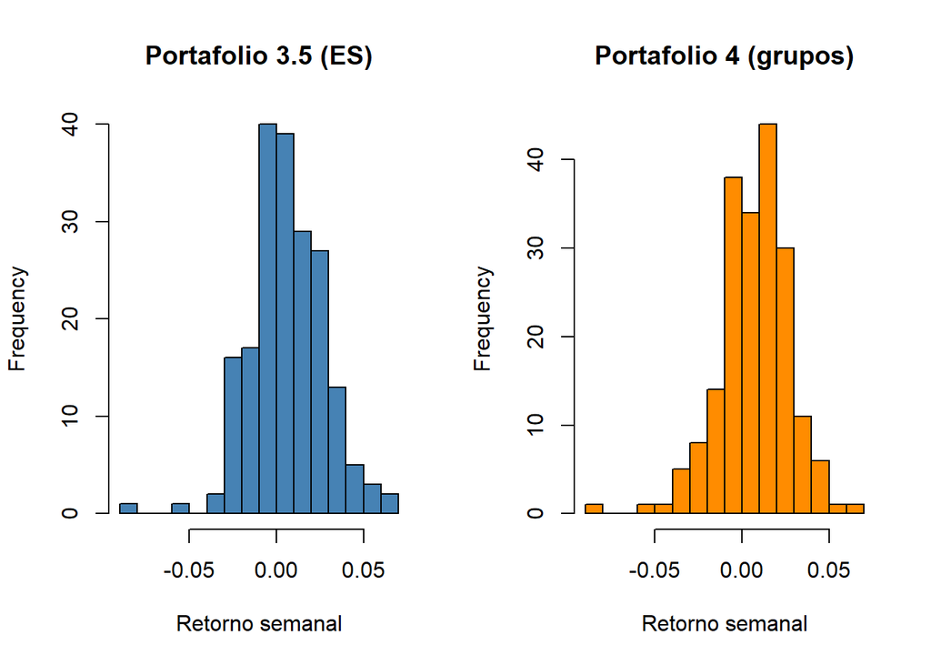

```r
par(mfrow = c(1, 2))
hist(pf35_sem, main = "Portafolio 3.5 (ES)", xlab = "Retorno semanal", col = "steelblue", breaks = 20)
hist(pf4_sem, main = "Portafolio 4 (grupos)", xlab = "Retorno semanal", col = "darkorange", breaks = 20)
```

```r
par(mfrow = c(1, 1))
```

**Respuesta a.** Se calcularon 195 retornos semanales con rebalanceo mensual. El portafolio 3.5 va de −8,35% a +6,94% con media de 0,65% semanal. El portafolio 4 va de −8,86% a +6,20% con media de 0,71%. Los dos histogramas son parecidos; el del portafolio 4 tiene más masa en la cola izquierda y un retorno medio algo mayor.

```r
sd_pf35 <- sd(pf35_sem); sd_pf4 <- sd(pf4_sem)
skew_pf35 <- PerformanceAnalytics::skewness(pf35_sem); skew_pf4 <- PerformanceAnalytics::skewness(pf4_sem)
kurt_pf35 <- PerformanceAnalytics::kurtosis(pf35_sem, method = "excess"); kurt_pf4 <- PerformanceAnalytics::kurtosis(pf4_sem, method = "excess")

tabla_5 <- data.frame(
  portafolio = c("3.5 (ES)", "4 (grupos)"),
  SD_semanal = c(sd_pf35, sd_pf4),
  Asimetria = c(skew_pf35, skew_pf4),
  Curtosis_exceso = c(kurt_pf35, kurt_pf4)
)
tabla_5
```

```
##   portafolio SD_semanal  Asimetria Curtosis_exceso
## 1   3.5 (ES) 0.02149411 -0.1660557        1.165721
## 2 4 (grupos) 0.02010277 -0.6789608        2.365993
```

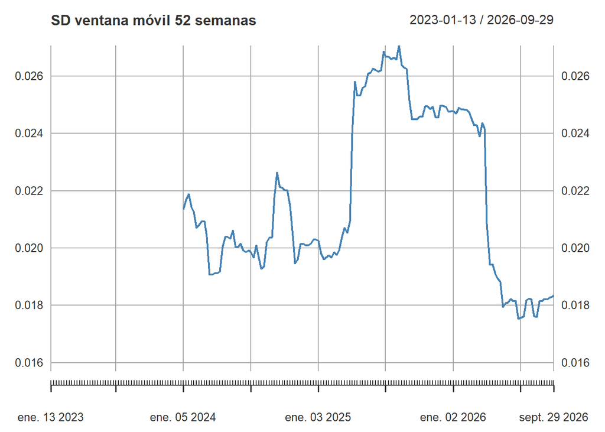

```r
roll_sd_35 <- zoo::rollapply(pf35_sem, width = 52, FUN = sd, align = "right")
roll_sd_4 <- zoo::rollapply(pf4_sem, width = 52, FUN = sd, align = "right")
roll_skew_35 <- zoo::rollapply(pf35_sem, width = 52, FUN = PerformanceAnalytics::skewness, align = "right")
roll_skew_4 <- zoo::rollapply(pf4_sem, width = 52, FUN = PerformanceAnalytics::skewness, align = "right")
roll_kurt_35 <- zoo::rollapply(pf35_sem, width = 52, FUN = function(x) PerformanceAnalytics::kurtosis(x, method = "excess"), align = "right")
roll_kurt_4 <- zoo::rollapply(pf4_sem, width = 52, FUN = function(x) PerformanceAnalytics::kurtosis(x, method = "excess"), align = "right")

plot(roll_sd_35, main = "SD ventana móvil 52 semanas", ylim = range(c(roll_sd_35, roll_sd_4), na.rm = T), col = "steelblue")
```

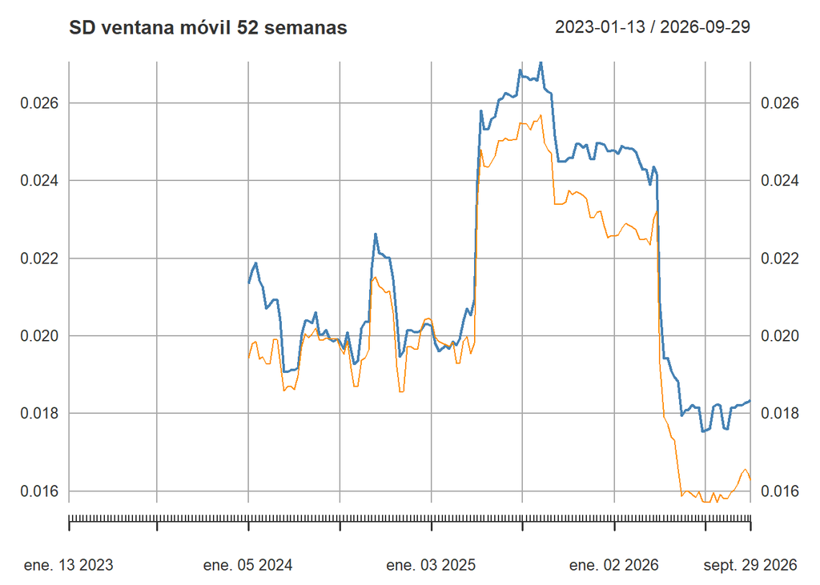

```r
lines(roll_sd_4, col = "darkorange")
legend("topright", legend = c("3.5 (ES)", "4 (grupos)"), col = c("steelblue", "darkorange"), lty = 1)
```

**Respuesta c.** Asimetría histórica: −0,166 para el 3.5 y −0,679 para el 4. Ambas son negativas, pero la del portafolio 4 es cuatro veces mayor: tiene más probabilidad de pérdidas extremas que de ganancias extremas.

**Respuesta d.** Asimetría en ventana móvil de 52 semanas: promedio −0,13 para el 3.5 (rango −0,67 a 0,49) y −0,64 para el 4 (rango −1,31 a −0,01). La del 3.5 llega a ser positiva en algunas ventanas; la del 4 es negativa en todas.

**Respuesta e.** Exceso de curtosis histórico: 1,17 para el 3.5 y 2,37 para el 4. Ambos son positivos (colas más pesadas que la normal) y el del portafolio 4 es el doble.

**Respuesta f.** Exceso de curtosis en ventana móvil de 52 semanas: promedio 0,77 para el 3.5 (rango −0,63 a 3,17) y 1,63 para el 4 (rango 0,03 a 5,51). El portafolio 4 tiene colas más pesadas en casi todas las ventanas.

**g. Pérdida esperada histórica en el 1% de los casos**

```r
es_pf35 <- PerformanceAnalytics::ES(pf35_sem, p = 0.99, method = "historical")
es_pf4 <- PerformanceAnalytics::ES(pf4_sem, p = 0.99, method = "historical")
tabla_5b <- data.frame(portafolio = c("3.5 (ES)", "4 (grupos)"), ES_1pct = c(as.numeric(es_pf35), as.numeric(es_pf4)))
tabla_5b
```

```
##   portafolio     ES_1pct
## 1   3.5 (ES) -0.06691132
## 2 4 (grupos) -0.07137121
```

**Respuesta g.** La pérdida esperada histórica al 1% es −6,69% semanal para el portafolio 3.5 y −7,14% para el portafolio 4. Con 195 semanas el 1% son solo 2 observaciones, así que la cifra es ruidosa. Aun así coincide con la lectura de asimetría y curtosis: el portafolio 4 tiene la cola de pérdidas más severa pese a su menor desviación estándar.